# R Notebook

```r
library(tidyverse)
library(lubridate)
```

## Question 1A

Here we read in the data using read csv and display it

```r
data <- "http://ritsokiguess.site/STAC33/sleeping.csv"
sleeping <- read_csv(data)
sleeping
```

| bed.time | rise.time | sleep.time |
| --- | --- | --- |
| 2013-09-01 23:05:24 | 2013-09-02 08:03:29 | 6.74 |
| 2013-09-02 22:51:09 | 2013-09-03 07:34:21 | 7.92 |
| 2013-09-04 00:09:16 | 2013-09-04 07:45:06 | 7.01 |
| 2013-09-04 23:43:31 | 2013-09-05 07:07:17 | 6.23 |
| 2013-09-06 00:17:41 | 2013-09-06 08:17:13 | 6.34 |
| 2013-09-06 22:42:27 | 2013-09-07 06:52:11 | 7.42 |
| 2013-09-08 00:22:27 | 2013-09-08 07:15:19 | 6.45 |

Our data shows the sleep.time in a double numeric variable with values such as 6.74 and 7.92. Meanwhile, bed.time and rise.time are both in the POSIXct variable type. These variables are formatted in a way that display the calendar date and time, specifically in a year-month-day format alongside a 24 clock time display. The first column displays the date and time of sleep while the second column indicates the wake time. The third column shows that amount of sleep received Typically, most of the data show that sleep time was around 7 hours with no student getting more than 8 hours or less than 6

## Question 1B

We work out the fractional number of hours that the student was in bed for each night using rise and bed times and then dividing by dhours(1) to obtain a fractional value

```r
sleeping %>%
  mutate(sleep.fractional = (rise.time - bed.time)/ dhours(1)) -> sleep.fractional
sleep.fractional
```

| bed.time | rise.time | sleep.time | sleep.fractional |
| --- | --- | --- | --- |
| 2013-09-01 23:05:24 | 2013-09-02 08:03:29 | 6.74 | 8.968056 |
| 2013-09-02 22:51:09 | 2013-09-03 07:34:21 | 7.92 | 8.720000 |
| 2013-09-04 00:09:16 | 2013-09-04 07:45:06 | 7.01 | 7.597222 |
| 2013-09-04 23:43:31 | 2013-09-05 07:07:17 | 6.23 | 7.396111 |
| 2013-09-06 00:17:41 | 2013-09-06 08:17:13 | 6.34 | 7.992222 |
| 2013-09-06 22:42:27 | 2013-09-07 06:52:11 | 7.42 | 8.162222 |
| 2013-09-08 00:22:27 | 2013-09-08 07:15:19 | 6.45 | 6.881111 |

All our data in the final column is a number we can use in further calculations

## Question 1C

We want to obtain data pertaining the student’s sleep effciency to see the percentage of time that was spent sleeping in bed. We calculate this by taking the sleep time and dividing it by the fractional time in bed we obtained earlier. We calculate this in a percentage form and display them.

```r
sleep.fractional %>%
  mutate(sleep_efficiency = (sleep.time / sleep.fractional)*100) -> sleep_efficiency
sleep_efficiency
```

| bed.time | rise.time | sleep.time | sleep.fractional | sleep_efficiency |
| --- | --- | --- | --- | --- |
| 2013-09-01 23:05:24 | 2013-09-02 08:03:29 | 6.74 | 8.968056 | 75.15565 |
| 2013-09-02 22:51:09 | 2013-09-03 07:34:21 | 7.92 | 8.720000 | 90.82569 |
| 2013-09-04 00:09:16 | 2013-09-04 07:45:06 | 7.01 | 7.597222 | 92.27057 |
| 2013-09-04 23:43:31 | 2013-09-05 07:07:17 | 6.23 | 7.396111 | 84.23346 |
| 2013-09-06 00:17:41 | 2013-09-06 08:17:13 | 6.34 | 7.992222 | 79.32712 |
| 2013-09-06 22:42:27 | 2013-09-07 06:52:11 | 7.42 | 8.162222 | 90.90662 |
| 2013-09-08 00:22:27 | 2013-09-08 07:15:19 | 6.45 | 6.881111 | 93.73486 |

```r
NA
```

From the data, the student’s sleep efficiency was the greatest on the seventh day with about a percentage of 93.7%. We also notice days 2, 3 and 6 come close at good efficiencys with a 90.8%, 92.3% and 90.9%.

## Question 1D

We want to display the time spend in bed each night as a metric of hours, minutes and seconds in number values.

```r
sleep.fractional %>%
  mutate(bed_time_spent = as.period(bed.time %--% rise.time)) %>%
  select(bed_time_spent)
```

| bed_time_spent |
| --- |
| 8H 58M 5S |
| 8H 43M 12S |
| 7H 35M 50S |
| 7H 23M 46S |
| 7H 59M 32S |
| 8H 9M 44S |
| 6H 52M 52S |

After mutating the data using the bed and rise times we can see the time spent in bed for each night.What’s intresting is the most effcient time that the student slept for was 6 hours, 52 minutes and 52 seconds.

## Question 1E

We make a graph of the time the student went to bed each night by choosing a scatterplot as there are only two quantitative variables present. Furthermore, we calculate and mutate the date to be showed as a metric of time in hours, minutes and seconds as this is more informative to look at.

```r
sleeping %>%
  select(bed.time) %>%
  mutate(hr = hour(bed.time), min = minute(bed.time), sec = second(bed.time)) %>%
  unite (sleep.time, hr, min, sec) %>% mutate(nights =1:7) %>%
  select(nights, sleep.time) -> time_of_sleep
```

We used the data of bed time and mutated it into a time we desire. We unite the seven nights so we can display the nights as one variable and the time of sleep as the other on the graph.

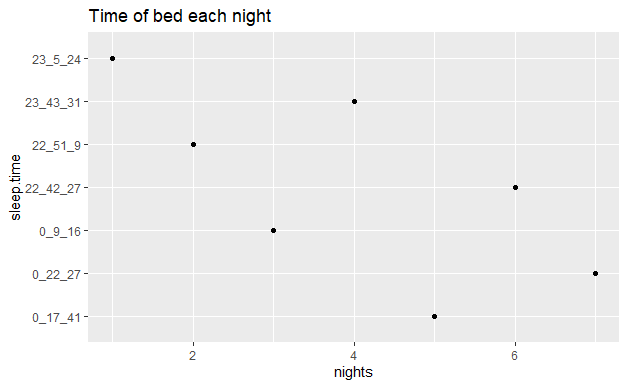

```r
ggplot(time_of_sleep, aes(x = nights, y = sleep.time)) + geom_point() + labs(title = "Time of bed each night")
```

## Question 2A

We read in data of height and foot using csv and display the information below.

```r
data <- "http://ritsokiguess.site/STAC32/heightfoot.csv"
heightfoot <- read_csv(data)
heightfoot
```

| height | foot |
| --- | --- |
| 66.5 | 27.0 |
| 73.5 | 29.0 |
| 70.0 | 25.5 |
| 71.0 | 27.9 |
| 73.0 | 27.0 |
| 71.0 | 26.0 |
| 71.0 | 29.0 |
| 69.5 | 27.0 |
| 73.0 | 29.0 |
| 71.0 | 27.0 |

[output cut: 23 more lines]

```r
NA
```

## Question 2B

We will obtain the least squares estimates of intercepts and slope for this regression using R’s vector-matrix algebra. This formula looks like: 𝛽 = ((𝑋̂𝑇*𝑋)^−1)(XT)Y

Our first step is to obtain the response variable values which are the length of foot and is the Y variable of the formula.

```r
y <- as.matrix(heightfoot %>% select(foot))
y
```

```
      foot
 [1,] 27.0
 [2,] 29.0
 [3,] 25.5
 [4,] 27.9
 [5,] 27.0
 [6,] 26.0
 [7,] 29.0
 [8,] 27.0
 [9,] 29.0
[10,] 27.0
[11,] 29.0
[12,] 27.2
[13,] 29.0
[14,] 29.0
```

[output cut: 19 more lines]

We want to create the matrix X which contains columns of 1s and the height variable column. This will allow us to transpose this matrix to finish our formula.

```r
matrix_ones <- matrix(1:1, nrow = nrow(y))
x <- cbind(matrix_ones, as.matrix(heightfoot %>% select(height)))
x
```

```
        height
 [1,] 1   66.5
 [2,] 1   73.5
 [3,] 1   70.0
 [4,] 1   71.0
 [5,] 1   73.0
 [6,] 1   71.0
 [7,] 1   71.0
 [8,] 1   69.5
 [9,] 1   73.0
[10,] 1   71.0
[11,] 1   69.0
[12,] 1   69.0
[13,] 1   73.0
[14,] 1   75.0
```

[output cut: 19 more lines]

We need the X^T or the matrix transpose of X to carry out the calculation pertaining it in the formula

```r
x.transpose <- t(x)
x.transpose
```

```
       [,1] [,2] [,3] [,4] [,5] [,6] [,7] [,8] [,9] [,10] [,11] [,12]
        1.0  1.0    1    1    1    1    1  1.0    1     1     1     1
height 66.5 73.5   70   71   73   71   71 69.5   73    71    69    69
       [,13] [,14] [,15] [,16] [,17] [,18] [,19] [,20] [,21] [,22] [,23]
           1     1     1     1     1     1   1.0     1     1     1     1
height    73    75    73    72    69    68  72.5    78    79    71    74
       [,24] [,25] [,26] [,27] [,28] [,29] [,30] [,31] [,32] [,33]
           1     1     1     1     1     1     1     1     1     1
height    66    71    71    71    84    77    72    70    76    68
```

Now we can solve the least squares estimates of intercepts

```r
least_squares <- (solve(x.transpose %*% x)) %*% x.transpose %*% y
least_squares
```

```
             foot
       10.9357703
height  0.2334397
```

NOw that we have calculate the least squares estimates formula, we get an intercept of about 10.94 and a slope of about 0.23.

## Question 2C

We want to verify our calculation is correct so we will run a regression and see if it holds up to the formula we calculated in the last step.

```r
regression_heightfoot <- lm(foot ~ height, data = heightfoot)
regression_heightfoot
```

```
Call:
lm(formula = foot ~ height, data = heightfoot)

Coefficients:
(Intercept)       height
    10.9358       0.2334
```

THe intercept of about 10.94 and the slope of about 0.23 all match up with the least squares estimate and slope of the regression.